# Introduction:-

## Period 4 (1990-2010)

```python
df4=df[(df['Year']>=1990)&(df['Year']<2010)]
```

```python
df4.describe()
```

|  | Year | Final_Standing | Games_Played | Unnamed: 7 | Games_Won | Games_Lost | Runs_Scored | At_Bats | Hits | Doubles | ... | Shutout | Saves | Infield_Put_Outs | Hits_Allowed | Home_Run_Allowed | Walks_Allowed | Strikeouts_Allowed | Errors | Double_Plays | Fielding_Percentage |
| --- | --- | --- | --- | --- | --- | --- | --- | --- | --- | --- | --- | --- | --- | --- | --- | --- | --- | --- | --- | --- | --- |
| count | 578.000000 | 578.000000 | 578.000000 | 578.000000 | 578.000000 | 578.000000 | 578.000000 | 578.000000 | 578.000000 | 578.000000 | ... | 578.000000 | 578.000000 | 578.000000 | 578.000000 | 578.000000 | 578.000000 | 578.000000 | 578.000000 | 578.000000 | 578.000000 |
| mean | 1999.754325 | 3.124567 | 158.771626 | 79.361592 | 79.365052 | 79.365052 | 749.415225 | 5443.204152 | 1442.638408 | 280.788927 | ... | 8.136678 | 40.043253 | 4250.558824 | 1442.634948 | 161.759516 | 537.344291 | 1010.866782 | 108.806228 | 148.723183 | 0.979974 |
| std | 5.710387 | 1.567118 | 10.763557 | 5.492618 | 12.348912 | 12.324608 | 94.213964 | 371.961748 | 119.489856 | 36.119824 | ... | 3.733358 | 7.874439 | 289.816707 | 126.184358 | 30.978317 | 74.427875 | 134.032438 | 18.939304 | 20.512148 | 0.004799 |
| min | 1990.000000 | 1.000000 | 112.000000 | 44.000000 | 43.000000 | 40.000000 | 466.000000 | 3856.000000 | 963.000000 | 159.000000 | ... | 0.000000 | 20.000000 | 2952.000000 | 929.000000 | 76.000000 | 288.000000 | 560.000000 | 57.000000 | 82.000000 | 0.970000 |
| 25% | 1995.000000 | 2.000000 | 162.000000 | 81.000000 | 71.000000 | 71.000000 | 688.250000 | 5480.250000 | 1399.250000 | 262.000000 | ... | 6.000000 | 35.000000 | 4297.250000 | 1385.000000 | 142.000000 | 489.000000 | 929.250000 | 95.250000 | 136.000000 | 0.980000 |
| 50% | 2000.000000 | 3.000000 | 162.000000 | 81.000000 | 79.000000 | 79.000000 | 747.000000 | 5535.000000 | 1454.000000 | 284.000000 | ... | 8.000000 | 40.000000 | 4329.000000 | 1453.000000 | 163.000000 | 537.000000 | 1015.000000 | 107.000000 | 150.000000 | 0.980000 |
| 75% | 2005.000000 | 4.000000 | 162.000000 | 81.000000 | 88.000000 | 88.000000 | 809.750000 | 5601.750000 | 1511.750000 | 304.000000 | ... | 11.000000 | 45.000000 | 4357.000000 | 1525.000000 | 183.000000 | 584.000000 | 1096.500000 | 122.000000 | 162.000000 | 0.983000 |
| max | 2009.000000 | 7.000000 | 163.000000 | 84.000000 | 116.000000 | 119.000000 | 1009.000000 | 5781.000000 | 1684.000000 | 376.000000 | ... | 24.000000 | 68.000000 | 4467.000000 | 1734.000000 | 241.000000 | 784.000000 | 1404.000000 | 173.000000 | 204.000000 | 0.989000 |

8 rows × 32 columns

```python
df4.corr(method='pearson',numeric_only='False')
```

|  | Year | Final_Standing | Games_Played | Unnamed: 7 | Games_Won | Games_Lost | Runs_Scored | At_Bats | Hits | Doubles | ... | Shutout | Saves | Infield_Put_Outs | Hits_Allowed | Home_Run_Allowed | Walks_Allowed | Strikeouts_Allowed | Errors | Double_Plays | Fielding_Percentage |
| --- | --- | --- | --- | --- | --- | --- | --- | --- | --- | --- | --- | --- | --- | --- | --- | --- | --- | --- | --- | --- | --- |
| Year | 1.000000 | -0.107352 | 0.283988 | 0.277515 | 0.124086 | 0.124330 | 0.286646 | 0.313859 | 0.319450 | 0.527540 | ... | 0.030275 | 0.006018 | 0.263700 | 0.302516 | 0.457301 | 0.087109 | 0.484901 | -0.304833 | 0.216581 | 0.602149 |
| Final_Standing | -0.107352 | 1.000000 | 0.054707 | 0.045699 | -0.734652 | 0.784864 | -0.427075 | 0.019478 | -0.189215 | -0.165760 | ... | -0.276035 | -0.458565 | 0.010630 | 0.290372 | 0.159982 | 0.309262 | -0.266267 | 0.303055 | 0.187352 | -0.234164 |
| Games_Played | 0.283988 | 0.054707 | 1.000000 | 0.980078 | 0.439008 | 0.433981 | 0.473063 | 0.978408 | 0.769363 | 0.528244 | ... | 0.345723 | 0.380938 | 0.991931 | 0.726720 | 0.344681 | 0.434202 | 0.552917 | 0.301507 | 0.489225 | 0.153049 |
| Unnamed: 7 | 0.277515 | 0.045699 | 0.980078 | 1.000000 | 0.434521 | 0.421092 | 0.467861 | 0.958905 | 0.756511 | 0.519716 | ... | 0.325513 | 0.378986 | 0.972855 | 0.719960 | 0.346374 | 0.418510 | 0.538039 | 0.284148 | 0.479078 | 0.163810 |
| Games_Won | 0.124086 | -0.734652 | 0.439008 | 0.434521 | 1.000000 | -0.618811 | 0.627709 | 0.456900 | 0.554099 | 0.393862 | ... | 0.533061 | 0.709256 | 0.487229 | 0.012052 | -0.111259 | -0.146569 | 0.495095 | -0.144582 | 0.051243 | 0.272719 |
| Games_Lost | 0.124330 | 0.784864 | 0.433981 | 0.421092 | -0.618811 | 1.000000 | -0.216235 | 0.397169 | 0.116928 | 0.066509 | ... | -0.231001 | -0.378716 | 0.378650 | 0.622535 | 0.412008 | 0.526540 | -0.012486 | 0.407927 | 0.376302 | -0.138527 |
| Runs_Scored | 0.286646 | -0.427075 | 0.473063 | 0.467861 | 0.627709 | -0.216235 | 1.000000 | 0.577673 | 0.816475 | 0.672303 | ... | 0.052452 | 0.276321 | 0.473684 | 0.499458 | 0.464099 | 0.239245 | 0.370264 | -0.012506 | 0.293278 | 0.213332 |
| At_Bats | 0.313859 | 0.019478 | 0.978408 | 0.958905 | 0.456900 | 0.397169 | 0.577673 | 1.000000 | 0.863709 | 0.608516 | ... | 0.300103 | 0.357336 | 0.977492 | 0.763843 | 0.401862 | 0.448472 | 0.553568 | 0.267144 | 0.505273 | 0.178106 |
| Hits | 0.319450 | -0.189215 | 0.769363 | 0.756511 | 0.554099 | 0.116928 | 0.816475 | 0.863709 | 1.000000 | 0.723739 | ... | 0.187956 | 0.329481 | 0.767899 | 0.686279 | 0.446227 | 0.351692 | 0.479361 | 0.110239 | 0.441705 | 0.218516 |
| Doubles | 0.527540 | -0.165760 | 0.528244 | 0.519716 | 0.393862 | 0.066509 | 0.672303 | 0.608516 | 0.723739 | 1.000000 | ... | 0.111875 | 0.169593 | 0.519272 | 0.510009 | 0.417354 | 0.223269 | 0.471160 | -0.046379 | 0.317290 | 0.346580 |
| Triples | -0.043209 | 0.014883 | 0.158189 | 0.152510 | 0.030072 | 0.108665 | 0.041599 | 0.159308 | 0.170564 | 0.071064 | ... | 0.067416 | 0.059706 | 0.155574 | 0.107074 | -0.004270 | 0.053374 | -0.005789 | 0.093818 | 0.044093 | -0.015077 |
| Home_Runs | 0.373986 | -0.353521 | 0.283593 | 0.276738 | 0.423865 | -0.177911 | 0.761587 | 0.357222 | 0.483923 | 0.466637 | ... | -0.051263 | 0.164089 | 0.279663 | 0.354890 | 0.479549 | 0.206877 | 0.354274 | -0.064143 | 0.197753 | 0.242211 |
| Walks | 0.081930 | -0.343058 | 0.410851 | 0.407903 | 0.537761 | -0.180357 | 0.650368 | 0.422824 | 0.445864 | 0.357307 | ... | 0.137389 | 0.274321 | 0.429261 | 0.294084 | 0.189905 | 0.237259 | 0.319099 | 0.020630 | 0.178185 | 0.089580 |
| Strike_Outs | 0.488025 | 0.063241 | 0.555172 | 0.543812 | 0.137599 | 0.347899 | 0.311627 | 0.537939 | 0.327416 | 0.402900 | ... | 0.056504 | 0.079795 | 0.545522 | 0.492396 | 0.419869 | 0.350036 | 0.502943 | 0.174332 | 0.251219 | 0.166934 |
| Stolen_Bases | -0.261464 | -0.062566 | 0.129099 | 0.118182 | 0.165352 | -0.053715 | 0.021711 | 0.100930 | 0.081330 | -0.118597 | ... | 0.093404 | 0.190319 | 0.148322 | -0.010562 | -0.106995 | -0.013763 | 0.001757 | 0.177396 | -0.093093 | -0.221979 |
| Caught_Stealing | -0.493359 | 0.118041 | 0.118987 | 0.110791 | 0.019056 | 0.085206 | -0.134499 | 0.060425 | 0.001079 | -0.255126 | ... | 0.038455 | 0.120538 | 0.132438 | 0.021224 | -0.164273 | -0.011073 | -0.154539 | 0.295693 | 0.006212 | -0.348360 |
| Hit_By_Pitch | -0.064956 | -0.046295 | -0.012764 | -0.020509 | 0.091551 | -0.093613 | 0.147622 | 0.005973 | -0.006828 | 0.078537 | ... | -0.024273 | 0.082971 | 0.046425 | 0.083709 | 0.058068 | -0.102987 | -0.051993 | 0.037608 | 0.030722 | -0.033875 |
| Sacrifice_Fly | -0.096238 | -0.261052 | 0.124981 | 0.077768 | 0.331581 | -0.327902 | 0.452753 | 0.234975 | 0.438456 | 0.274018 | ... | 0.031111 | 0.120780 | 0.098708 | 0.008983 | 0.008404 | -0.120647 | -0.022117 | -0.121443 | 0.028124 | 0.116052 |
| Runs_Against | 0.274440 | 0.402194 | 0.449139 | 0.445515 | -0.282918 | 0.675790 | 0.421788 | 0.504351 | 0.495537 | 0.409047 | ... | -0.397645 | -0.230457 | 0.392136 | 0.859853 | 0.769173 | 0.625464 | 0.056147 | 0.313759 | 0.462190 | -0.027149 |
| Earned_Runs | 0.318483 | 0.374340 | 0.444810 | 0.442029 | -0.261973 | 0.651068 | 0.439933 | 0.503358 | 0.507843 | 0.428889 | ... | -0.392343 | -0.219752 | 0.388300 | 0.854341 | 0.796653 | 0.618471 | 0.066489 | 0.207732 | 0.464609 | 0.062723 |
| Earned_Run_Average | 0.191278 | 0.396296 | -0.073155 | -0.063100 | -0.550992 | 0.488004 | 0.206467 | -0.002989 | 0.116116 | 0.169356 | ... | -0.624175 | -0.465825 | -0.137924 | 0.533419 | 0.684762 | 0.437778 | -0.250572 | 0.062576 | 0.237238 | -0.018543 |
| Complete_Games | -0.607178 | 0.012466 | -0.040015 | -0.045660 | 0.082703 | -0.117801 | -0.127248 | -0.075902 | -0.122410 | -0.275805 | ... | 0.269633 | -0.067172 | -0.023488 | -0.202871 | -0.382544 | -0.098004 | -0.198705 | 0.169458 | -0.073061 | -0.365525 |
| Shutout | 0.030275 | -0.276035 | 0.345723 | 0.325513 | 0.533061 | -0.231001 | 0.052452 | 0.300103 | 0.187956 | 0.111875 | ... | 1.000000 | 0.385527 | 0.377445 | -0.132942 | -0.333169 | -0.148247 | 0.356846 | -0.062446 | 0.032496 | 0.139880 |
| Saves | 0.006018 | -0.458565 | 0.380938 | 0.378986 | 0.709256 | -0.378716 | 0.276321 | 0.357336 | 0.329481 | 0.169593 | ... | 0.385527 | 1.000000 | 0.417707 | 0.031112 | -0.130450 | -0.109214 | 0.306534 | -0.011681 | 0.031931 | 0.135552 |
| Infield_Put_Outs | 0.263700 | 0.010630 | 0.991931 | 0.972855 | 0.487229 | 0.378650 | 0.473684 | 0.977492 | 0.767899 | 0.519272 | ... | 0.377445 | 0.417707 | 1.000000 | 0.690255 | 0.302596 | 0.407504 | 0.572717 | 0.287119 | 0.470658 | 0.158019 |
| Hits_Allowed | 0.302516 | 0.290372 | 0.726720 | 0.719960 | 0.012052 | 0.622535 | 0.499458 | 0.763843 | 0.686279 | 0.510009 | ... | -0.132942 | 0.031112 | 0.690255 | 1.000000 | 0.636726 | 0.467886 | 0.184412 | 0.325109 | 0.585791 | 0.067201 |
| Home_Run_Allowed | 0.457301 | 0.159982 | 0.344681 | 0.346374 | -0.111259 | 0.412008 | 0.464099 | 0.401862 | 0.446227 | 0.417354 | ... | -0.333169 | -0.130450 | 0.302596 | 0.636726 | 1.000000 | 0.373729 | 0.185172 | 0.007952 | 0.307856 | 0.220254 |
| Walks_Allowed | 0.087109 | 0.309262 | 0.434202 | 0.418510 | -0.146569 | 0.526540 | 0.239245 | 0.448472 | 0.351692 | 0.223269 | ... | -0.148247 | -0.109214 | 0.407504 | 0.467886 | 0.373729 | 1.000000 | 0.207982 | 0.268276 | 0.415647 | -0.065402 |
| Strikeouts_Allowed | 0.484901 | -0.266267 | 0.552917 | 0.538039 | 0.495095 | -0.012486 | 0.370264 | 0.553568 | 0.479361 | 0.471160 | ... | 0.356846 | 0.306534 | 0.572717 | 0.184412 | 0.185172 | 0.207982 | 1.000000 | -0.007551 | 0.012996 | 0.282031 |
| Errors | -0.304833 | 0.303055 | 0.301507 | 0.284148 | -0.144582 | 0.407927 | -0.012506 | 0.267144 | 0.110239 | -0.046379 | ... | -0.062446 | -0.011681 | 0.287119 | 0.325109 | 0.007952 | 0.268276 | -0.007551 | 1.000000 | 0.109486 | -0.732520 |
| Double_Plays | 0.216581 | 0.187352 | 0.489225 | 0.479078 | 0.051243 | 0.376302 | 0.293278 | 0.505273 | 0.441705 | 0.317290 | ... | 0.032496 | 0.031931 | 0.470658 | 0.585791 | 0.307856 | 0.415647 | 0.012996 | 0.109486 | 1.000000 | 0.153627 |
| Fielding_Percentage | 0.602149 | -0.234164 | 0.153049 | 0.163810 | 0.272719 | -0.138527 | 0.213332 | 0.178106 | 0.218516 | 0.346580 | ... | 0.139880 | 0.135552 | 0.158019 | 0.067201 | 0.220254 | -0.065402 | 0.282031 | -0.732520 | 0.153627 | 1.000000 |

32 rows × 32 columns

### Correlation cofficients for period 4

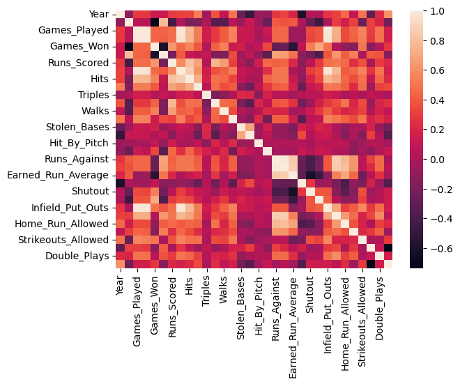

```python
sns.heatmap(df4.corr(method='pearson',numeric_only='True'))
```

```python
df4.corr(method='pearson',numeric_only=True).loc['Games_Won'][off_def].sort_values(ascending=False, key=abs)[:8]
```

```
Saves                 0.709256
Runs_Scored           0.627709
Hits                  0.554099
Earned_Run_Average   -0.550992
Walks                 0.537761
Shutout               0.533061
Strikeouts_Allowed    0.495095
Infield_Put_Outs      0.487229
Name: Games_Won, dtype: float64
```

#### Top 8 variables for time period 4 - Offensive - Runs Scored , Hits , Walks, Defensive - Earned Run Average , Shutout , Saves, Infield Put Out , Strike out allowed.¶ So the period 4 is also balanced in game style .

```python
df4.describe()
```

|  | Year | Final_Standing | Games_Played | Unnamed: 7 | Games_Won | Games_Lost | Runs_Scored | At_Bats | Hits | Doubles | ... | Shutout | Saves | Infield_Put_Outs | Hits_Allowed | Home_Run_Allowed | Walks_Allowed | Strikeouts_Allowed | Errors | Double_Plays | Fielding_Percentage |
| --- | --- | --- | --- | --- | --- | --- | --- | --- | --- | --- | --- | --- | --- | --- | --- | --- | --- | --- | --- | --- | --- |
| count | 578.000000 | 578.000000 | 578.000000 | 578.000000 | 578.000000 | 578.000000 | 578.000000 | 578.000000 | 578.000000 | 578.000000 | ... | 578.000000 | 578.000000 | 578.000000 | 578.000000 | 578.000000 | 578.000000 | 578.000000 | 578.000000 | 578.000000 | 578.000000 |
| mean | 1999.754325 | 3.124567 | 158.771626 | 79.361592 | 79.365052 | 79.365052 | 749.415225 | 5443.204152 | 1442.638408 | 280.788927 | ... | 8.136678 | 40.043253 | 4250.558824 | 1442.634948 | 161.759516 | 537.344291 | 1010.866782 | 108.806228 | 148.723183 | 0.979974 |
| std | 5.710387 | 1.567118 | 10.763557 | 5.492618 | 12.348912 | 12.324608 | 94.213964 | 371.961748 | 119.489856 | 36.119824 | ... | 3.733358 | 7.874439 | 289.816707 | 126.184358 | 30.978317 | 74.427875 | 134.032438 | 18.939304 | 20.512148 | 0.004799 |
| min | 1990.000000 | 1.000000 | 112.000000 | 44.000000 | 43.000000 | 40.000000 | 466.000000 | 3856.000000 | 963.000000 | 159.000000 | ... | 0.000000 | 20.000000 | 2952.000000 | 929.000000 | 76.000000 | 288.000000 | 560.000000 | 57.000000 | 82.000000 | 0.970000 |
| 25% | 1995.000000 | 2.000000 | 162.000000 | 81.000000 | 71.000000 | 71.000000 | 688.250000 | 5480.250000 | 1399.250000 | 262.000000 | ... | 6.000000 | 35.000000 | 4297.250000 | 1385.000000 | 142.000000 | 489.000000 | 929.250000 | 95.250000 | 136.000000 | 0.980000 |
| 50% | 2000.000000 | 3.000000 | 162.000000 | 81.000000 | 79.000000 | 79.000000 | 747.000000 | 5535.000000 | 1454.000000 | 284.000000 | ... | 8.000000 | 40.000000 | 4329.000000 | 1453.000000 | 163.000000 | 537.000000 | 1015.000000 | 107.000000 | 150.000000 | 0.980000 |
| 75% | 2005.000000 | 4.000000 | 162.000000 | 81.000000 | 88.000000 | 88.000000 | 809.750000 | 5601.750000 | 1511.750000 | 304.000000 | ... | 11.000000 | 45.000000 | 4357.000000 | 1525.000000 | 183.000000 | 584.000000 | 1096.500000 | 122.000000 | 162.000000 | 0.983000 |
| max | 2009.000000 | 7.000000 | 163.000000 | 84.000000 | 116.000000 | 119.000000 | 1009.000000 | 5781.000000 | 1684.000000 | 376.000000 | ... | 24.000000 | 68.000000 | 4467.000000 | 1734.000000 | 241.000000 | 784.000000 | 1404.000000 | 173.000000 | 204.000000 | 0.989000 |

8 rows × 32 columns

# Descriptive Statistics of Period 4 :-

## Histogram of each 8 variables of Period 4:-

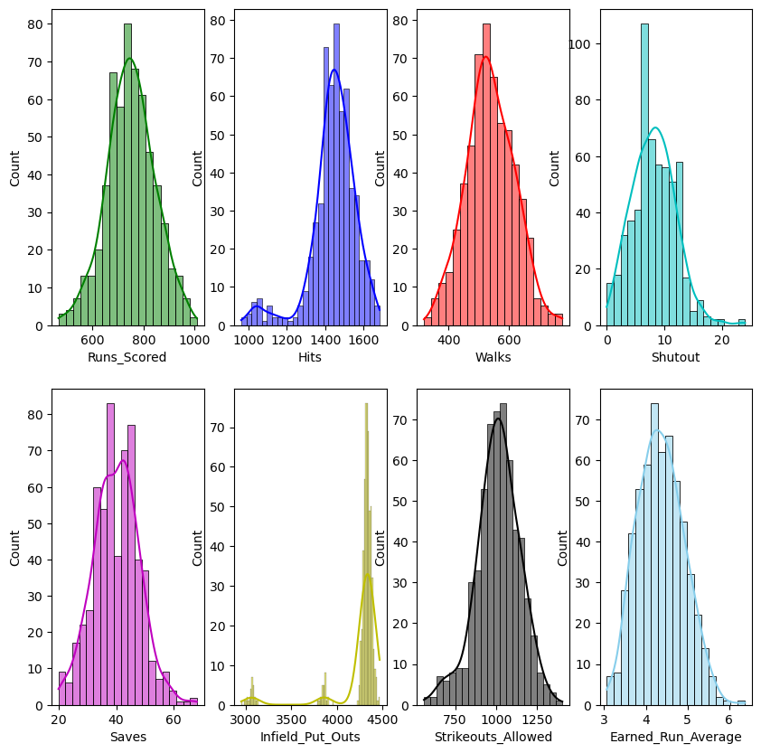

```python
fig, axs=plt.subplots(2,4,figsize=(10,10))

sns.histplot(data=df4,x='Runs_Scored',kde=True,ax=axs[0,0],color='g')

sns.histplot(data=df4,x='Hits',kde=True,ax=axs[0,1],color='b')

sns.histplot(data=df4,x='Walks',kde=True,ax=axs[0,2],color='r')

sns.histplot(data=df4,x='Shutout',kde=True,ax=axs[0,3],color='c')

sns.histplot(data=df4,x='Saves',kde=True,ax=axs[1,0],color='m')

sns.histplot(data=df4,x='Infield_Put_Outs',kde=True,ax=axs[1,1],color='y')

sns.histplot(data=df4,x='Strikeouts_Allowed',kde=True,ax=axs[1,2],color='k')

sns.histplot(data=df4,x='Earned_Run_Average',kde=True,ax=axs[1,3],color='skyblue')
```

## BoxPlot for each top 8 variables of Period 4:-

### multiple box subplot

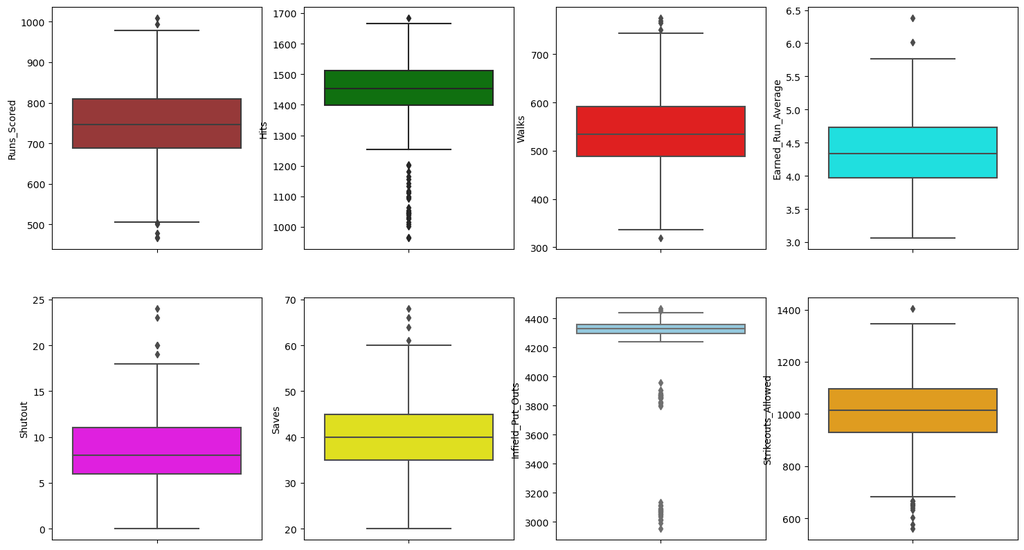

```python
fig, axes = plt.subplots(2, 4, figsize=(18, 10))
sns.boxplot(ax=axes[0, 0], data=df4, y='Runs_Scored', color='brown')
sns.boxplot(ax=axes[0, 1], data=df4,  y='Hits',color='green')
sns.boxplot(ax=axes[0, 2], data=df4,  y='Walks',color='red')
sns.boxplot(ax=axes[0, 3], data=df4, y='Earned_Run_Average',color='cyan')
sns.boxplot(ax=axes[1, 0], data=df4, y='Shutout',color='magenta')
sns.boxplot(ax=axes[1, 1], data=df4,  y='Saves',color='yellow')
sns.boxplot(ax=axes[1, 2], data=df4,  y='Infield_Put_Outs',color='skyblue')
sns.boxplot(ax=axes[1, 3], data=df4,  y='Strikeouts_Allowed',color='orange')
```

### Paired scattered plots

```python
warnings.filterwarnings("ignore", category=UserWarning)
```

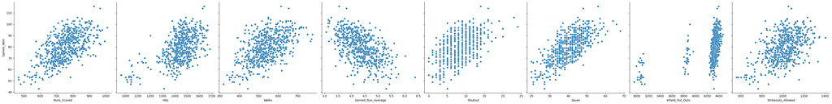

```python
sns.pairplot(df4,x_vars=['Runs_Scored','Hits','Walks','Earned_Run_Average','Shutout','Saves','Infield_Put_Outs','Strikeouts_Allowed'],y_vars='Games_Won',height=5)
```

```python
warnings.resetwarnings()
```

##### QQ Plot for Period 4:-

```python
import pylab
import scipy.stats as stats
```

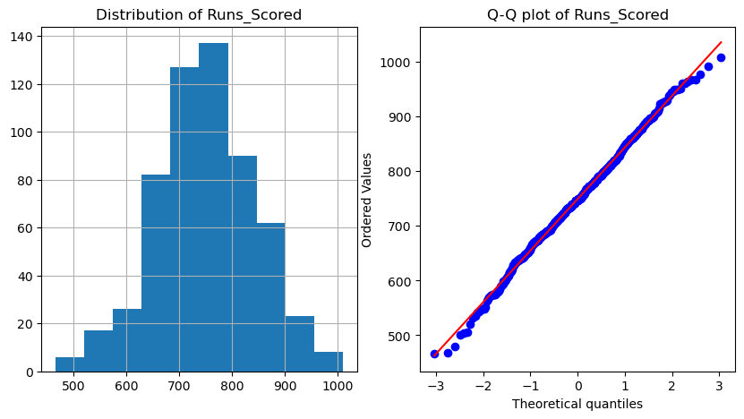

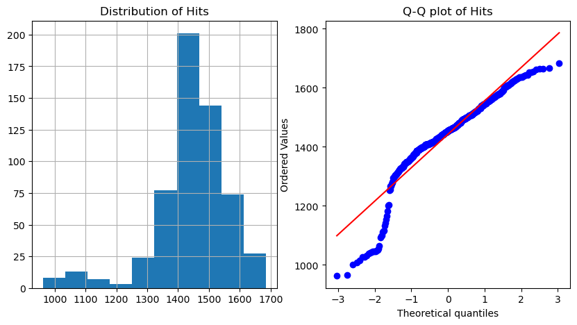

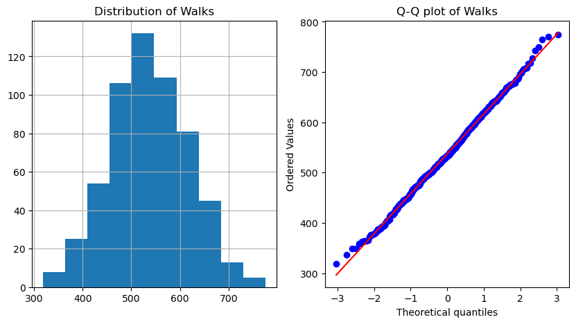

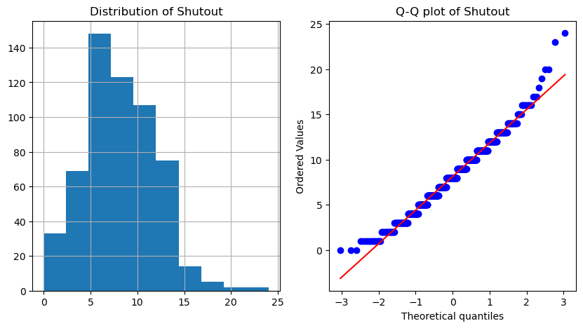

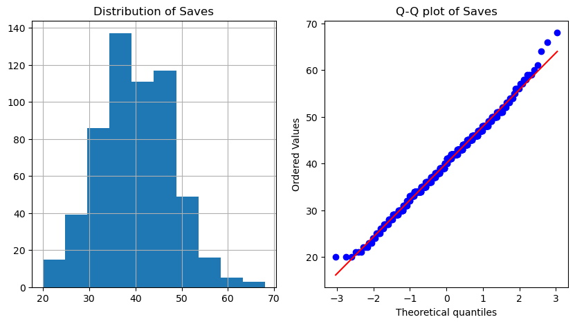

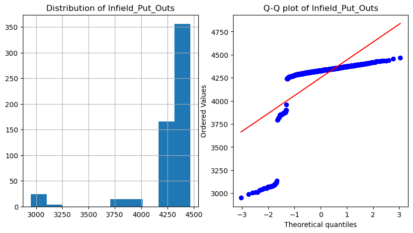

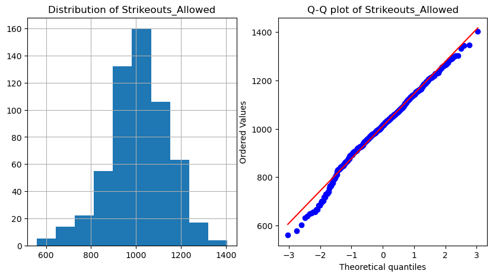

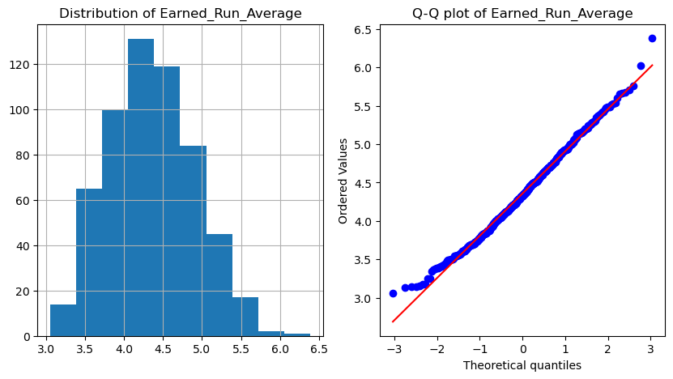

```python
for var in ['Runs_Scored', 'Hits', 'Walks', 'Shutout', 'Saves', 'Infield_Put_Outs','Strikeouts_Allowed','Earned_Run_Average']:
    plt.figure(figsize=(10,5))

    plt.subplot(1, 2, 1)
    df4[var].hist()
    plt.title('Distribution of '+ var)

    plt.subplot(1, 2, 2)
    stats.probplot(df4[var], dist="norm", plot=pylab)
    plt.title('Q-Q plot of '+ var)

    plt.show()
```

## Comment on Visual Shape of each Distribution Variable:-

#### 1. Runs_Scored:- In my guess, It is Symmetric (Bell Shaped)

#### 2. Hits :- Skewed Left (negatively skewed)

#### 3. Walks :- Symmetric (Bell Shaped)

#### 4. Earned_Run_Average :- Symmetric (Bell Shaped)

#### 5. Shutout :- Symmetric (Bell Shaped) or Skewed Right

#### 6. Saves :- Symmetric (Bell Shaped)

#### 7. Infield_put_outs:- Skewed Left (negatively skewed)

#### 8. Strikeouts_Allowed :- Symmetric (Bell Shaped)

# Section 4:-

## Linear Regression :-

### Entering the realm of model development, we iteratively construct linear regression models. Balancing significance and integrity through R2, R2 Adjusted, and F-Statistics, we meticulously ensure that selected independent variables exhibit statistical significance based on t-statistics and p-values. Feature engineering decisions are documented to achieve the desired model performance.

```python
x_train,x_test,y_train,y_test=train_test_split(df4,df4['Games_Won'],train_size=0.7,random_state=1)
```

```python
x_train.describe()
```

|  | Year | Final_Standing | Games_Played | Unnamed: 7 | Games_Won | Games_Lost | Runs_Scored | At_Bats | Hits | Doubles | ... | Shutout | Saves | Infield_Put_Outs | Hits_Allowed | Home_Run_Allowed | Walks_Allowed | Strikeouts_Allowed | Errors | Double_Plays | Fielding_Percentage |
| --- | --- | --- | --- | --- | --- | --- | --- | --- | --- | --- | --- | --- | --- | --- | --- | --- | --- | --- | --- | --- | --- |
| count | 404.000000 | 404.000000 | 404.000000 | 404.000000 | 404.000000 | 404.000000 | 404.000000 | 404.000000 | 404.000000 | 404.000000 | ... | 404.000000 | 404.000000 | 404.000000 | 404.000000 | 404.000000 | 404.000000 | 404.000000 | 404.000000 | 404.000000 | 404.000000 |
| mean | 1999.539604 | 3.175743 | 158.898515 | 79.418317 | 79.163366 | 79.690594 | 751.759901 | 5450.626238 | 1446.482673 | 281.349010 | ... | 8.103960 | 39.883663 | 4253.821782 | 1446.331683 | 162.210396 | 537.430693 | 1006.037129 | 109.804455 | 148.586634 | 0.979755 |
| std | 5.602721 | 1.574078 | 10.393838 | 5.328025 | 12.240073 | 12.393900 | 95.483252 | 361.617316 | 119.168989 | 36.282042 | ... | 3.755437 | 7.678647 | 280.700016 | 123.530384 | 31.047035 | 74.858992 | 131.230920 | 19.048427 | 20.370024 | 0.004886 |
| min | 1990.000000 | 1.000000 | 112.000000 | 44.000000 | 43.000000 | 40.000000 | 466.000000 | 3861.000000 | 963.000000 | 159.000000 | ... | 0.000000 | 20.000000 | 2952.000000 | 929.000000 | 76.000000 | 288.000000 | 560.000000 | 65.000000 | 85.000000 | 0.970000 |
| 25% | 1995.000000 | 2.000000 | 162.000000 | 81.000000 | 70.000000 | 71.000000 | 687.500000 | 5481.000000 | 1399.000000 | 260.000000 | ... | 6.000000 | 34.750000 | 4297.000000 | 1395.000000 | 142.750000 | 489.000000 | 926.000000 | 96.000000 | 134.000000 | 0.980000 |
| 50% | 2000.000000 | 3.000000 | 162.000000 | 81.000000 | 79.000000 | 79.000000 | 749.500000 | 5536.000000 | 1457.000000 | 284.000000 | ... | 8.000000 | 41.000000 | 4326.500000 | 1452.500000 | 163.000000 | 535.500000 | 1004.000000 | 108.000000 | 149.000000 | 0.980000 |
| 75% | 2004.000000 | 4.000000 | 162.000000 | 81.000000 | 88.000000 | 88.000000 | 810.250000 | 5604.250000 | 1516.500000 | 305.000000 | ... | 10.000000 | 45.000000 | 4356.250000 | 1524.250000 | 183.000000 | 584.500000 | 1088.000000 | 122.000000 | 162.000000 | 0.983000 |
| max | 2009.000000 | 7.000000 | 163.000000 | 84.000000 | 116.000000 | 119.000000 | 1009.000000 | 5781.000000 | 1684.000000 | 376.000000 | ... | 24.000000 | 61.000000 | 4467.000000 | 1734.000000 | 241.000000 | 784.000000 | 1333.000000 | 173.000000 | 204.000000 | 0.989000 |

8 rows × 32 columns

```python
x_test.describe()
```

|  | Year | Final_Standing | Games_Played | Unnamed: 7 | Games_Won | Games_Lost | Runs_Scored | At_Bats | Hits | Doubles | ... | Shutout | Saves | Infield_Put_Outs | Hits_Allowed | Home_Run_Allowed | Walks_Allowed | Strikeouts_Allowed | Errors | Double_Plays | Fielding_Percentage |
| --- | --- | --- | --- | --- | --- | --- | --- | --- | --- | --- | --- | --- | --- | --- | --- | --- | --- | --- | --- | --- | --- |
| count | 174.000000 | 174.000000 | 174.000000 | 174.000000 | 174.000000 | 174.000000 | 174.000000 | 174.000000 | 174.000000 | 174.000000 | ... | 174.000000 | 174.000000 | 174.000000 | 174.000000 | 174.000000 | 174.000000 | 174.000000 | 174.000000 | 174.000000 | 174.000000 |
| mean | 2000.252874 | 3.005747 | 158.477011 | 79.229885 | 79.833333 | 78.609195 | 743.971264 | 5425.971264 | 1433.712644 | 279.488506 | ... | 8.212644 | 40.413793 | 4242.982759 | 1434.051724 | 160.712644 | 537.143678 | 1022.080460 | 106.488506 | 149.040230 | 0.980483 |
| std | 5.939421 | 1.548809 | 11.602623 | 5.870867 | 12.621242 | 12.163963 | 91.236175 | 395.480865 | 120.100383 | 35.810474 | ... | 3.691211 | 8.322338 | 310.665079 | 132.107342 | 30.881990 | 73.631146 | 140.066848 | 18.530630 | 20.894273 | 0.004564 |
| min | 1990.000000 | 1.000000 | 112.000000 | 53.000000 | 47.000000 | 46.000000 | 479.000000 | 3856.000000 | 966.000000 | 160.000000 | ... | 1.000000 | 20.000000 | 2991.000000 | 964.000000 | 90.000000 | 332.000000 | 602.000000 | 57.000000 | 82.000000 | 0.970000 |
| 25% | 1995.000000 | 2.000000 | 162.000000 | 81.000000 | 71.000000 | 70.000000 | 690.000000 | 5478.250000 | 1400.000000 | 264.250000 | ... | 5.000000 | 36.000000 | 4302.000000 | 1373.500000 | 141.000000 | 492.500000 | 932.000000 | 94.000000 | 137.250000 | 0.980000 |
| 50% | 2001.000000 | 3.000000 | 162.000000 | 81.000000 | 79.000000 | 78.500000 | 743.000000 | 5533.000000 | 1447.500000 | 283.500000 | ... | 8.000000 | 39.000000 | 4332.000000 | 1453.000000 | 163.000000 | 543.000000 | 1036.000000 | 105.000000 | 151.000000 | 0.980000 |
| 75% | 2005.000000 | 4.000000 | 162.000000 | 81.000000 | 88.750000 | 88.000000 | 807.250000 | 5595.250000 | 1506.000000 | 302.750000 | ... | 11.000000 | 45.750000 | 4359.000000 | 1526.500000 | 182.750000 | 584.000000 | 1115.000000 | 118.750000 | 163.000000 | 0.984000 |
| max | 2009.000000 | 7.000000 | 163.000000 | 84.000000 | 114.000000 | 106.000000 | 965.000000 | 5716.000000 | 1644.000000 | 353.000000 | ... | 18.000000 | 68.000000 | 4410.000000 | 1640.000000 | 239.000000 | 728.000000 | 1404.000000 | 158.000000 | 192.000000 | 0.989000 |

8 rows × 32 columns

### Final Model:-

```python
lm1=smf.ols(formula='Games_Won ~ Runs_Scored+Earned_Run_Average+Shutout+Saves', data=df4).fit()
lm1.summary()
```

OLS Regression Results

| Dep. Variable: | Games_Won | R-squared: | 0.923 |
| --- | --- | --- | --- |
| Model: | OLS | Adj. R-squared: | 0.923 |
| Method: | Least Squares | F-statistic: | 1722. |
| Date: | Tue, 19 Dec 2023 | Prob (F-statistic): | 1.24e-317 |
| Time: | 14:42:59 | Log-Likelihood: | -1530.8 |
| No. Observations: | 578 | AIC: | 3072. |
| Df Residuals: | 573 | BIC: | 3093. |
| Df Model: | 4 |  |  |
| Covariance Type: | nonrobust |  |  |

|  | coef | std err | t | P>\|t\| | [0.025 | 0.975] |
| --- | --- | --- | --- | --- | --- | --- |
| Intercept | 47.6309 | 2.142 | 22.234 | 0.000 | 43.423 | 51.838 |
| Runs_Scored | 0.0867 | 0.002 | 49.455 | 0.000 | 0.083 | 0.090 |
| Earned_Run_Average | -11.7491 | 0.388 | -30.249 | 0.000 | -12.512 | -10.986 |
| Shutout | 0.2443 | 0.050 | 4.838 | 0.000 | 0.145 | 0.344 |
| Saves | 0.3989 | 0.023 | 17.536 | 0.000 | 0.354 | 0.444 |

| Omnibus: | 0.497 | Durbin-Watson: | 2.073 |
| --- | --- | --- | --- |
| Prob(Omnibus): | 0.780 | Jarque-Bera (JB): | 0.365 |
| Skew: | 0.048 | Prob(JB): | 0.833 |
| Kurtosis: | 3.077 | Cond. No. | 1.15e+04 |

Notes:  
[1] Standard Errors assume that the covariance matrix of the errors is correctly specified.  
[2] The condition number is large, 1.15e+04. This might indicate that there are  
strong multicollinearity or other numerical problems.

### Runs_Scored, Earned_Run_Average, Shutout, Saves are our main feature variables for our multiple linear regression model.

# Section 5:-

## Model Validation :-

#### Model Testing :-

```python
lm1_predict=lm1.predict(x_test)
predict_values=pd.concat([x_test['Games_Won'],lm1_predict],axis=1)
predict_values.columns=['actual_Games_Won','predicted_Games_Won']
predict_values['residual']=predict_values['actual_Games_Won']-predict_values['predicted_Games_Won']
predict_values.head()
```

|  | actual_Games_Won | predicted_Games_Won | residual |
| --- | --- | --- | --- |
| 2239 | 98 | 98.077729 | -0.077729 |
| 2466 | 86 | 86.556862 | -0.556862 |
| 2397 | 84 | 85.419498 | -1.419498 |
| 2457 | 92 | 91.598573 | 0.401427 |
| 2527 | 88 | 88.178492 | -0.178492 |

```python
mae=metrics.mean_absolute_error(predict_values['actual_Games_Won'], predict_values['predicted_Games_Won'])
mse=metrics.mean_squared_error(predict_values['actual_Games_Won'], predict_values['predicted_Games_Won'])
rmse=np.sqrt(metrics.mean_squared_error(predict_values['actual_Games_Won'], predict_values['predicted_Games_Won']))
print('Mean Absolute Error', mae)
print('Mean Suare Error ', mse)
print('Root Mean Squared Error', rmse)
```

```
Mean Absolute Error 2.624246108829727
Mean Suare Error  10.819095853248406
Root Mean Squared Error 3.289239403456125
```

```python
accuracy = 100 - np.mean(rmse)
print('Accuracy is :' , round(accuracy,2), '%')
```

```
Accuracy is : 96.71 %
```

### p<0.05, R-squared: 0.923, adjusted R-squared: 0.923, F-statistic: 1722. , Prob (F-statistic): 1.24e-317

#### These values for our model showing a good indication that our model is a good predictive.

##### RMSE value 3.289239403456125 shows that our errors are under 5%.

##### Accuracy percentage is 96.71%

# Section 6:-

## Predictions :

##### Transitioning to the predictions section, our model steps into the realm of practical application. Predicted values, akin to deploying the model in production, are generated to address the original business questions. Model error metrics, derived from historical data, supplement our evaluation, contributing to the final assessment of meeting both business and analytical objectives.

```python
df5=df[(df['Year']==2012)&(df['Team_Name'] == 'New York Yankees')]
```

```python
df5.head()
```

|  | Year | League | Team | Franchise | Division | Final_Standing | Games_Played | Unnamed: 7 | Games_Won | Games_Lost | ... | Hits_Allowed | Home_Run_Allowed | Walks_Allowed | Strikeouts_Allowed | Errors | Double_Plays | Fielding_Percentage | Team_Name | Home_Ball_Park | Attendance |
| --- | --- | --- | --- | --- | --- | --- | --- | --- | --- | --- | --- | --- | --- | --- | --- | --- | --- | --- | --- | --- | --- |
| 2702 | 2012 | AL | NYA | NYY | E | 1 | 162 | 81.0 | 95 | 67 | ... | 1401 | 190 | 431 | 1318 | 75 | 135.0 | 0.987 | New York Yankees | Yankee Stadium III | 3542406 |

1 rows × 43 columns

```python
lm1_predict=lm1.predict(df5)
predict_values=pd.concat([df5['Games_Won'],lm1_predict],axis=1)
predict_values.columns=['actual_Games_Won','predicted_Games_Won']
predict_values['residual']=predict_values['actual_Games_Won']-predict_values['predicted_Games_Won']
predict_values.head()
```

|  | actual_Games_Won | predicted_Games_Won | residual |
| --- | --- | --- | --- |
| 2702 | 95 | 94.770908 | 0.229092 |

```python
mae=metrics.mean_absolute_error(predict_values['actual_Games_Won'], predict_values['predicted_Games_Won'])
mse=metrics.mean_squared_error(predict_values['actual_Games_Won'], predict_values['predicted_Games_Won'])
rmse=np.sqrt(metrics.mean_squared_error(predict_values['actual_Games_Won'], predict_values['predicted_Games_Won']))
print('Mean Absolute Error', mae)
print('Mean Suare Error ', mse)
print('Root Mean Squared Error', rmse)
```

```
Mean Absolute Error 0.22909190363127152
Mean Suare Error  0.052483100309399795
Root Mean Squared Error 0.22909190363127152
```

```python
df6=df[(df['Year']==2012)&(df['Team_Name'] == 'Toronto Blue Jays')]
```

```python
df6.head()
```

|  | Year | League | Team | Franchise | Division | Final_Standing | Games_Played | Unnamed: 7 | Games_Won | Games_Lost | ... | Hits_Allowed | Home_Run_Allowed | Walks_Allowed | Strikeouts_Allowed | Errors | Double_Plays | Fielding_Percentage | Team_Name | Home_Ball_Park | Attendance |
| --- | --- | --- | --- | --- | --- | --- | --- | --- | --- | --- | --- | --- | --- | --- | --- | --- | --- | --- | --- | --- | --- |
| 2713 | 2012 | AL | TOR | TOR | E | 4 | 162 | 81.0 | 73 | 89 | ... | 1439 | 204 | 574 | 1142 | 101 | 167.0 | 0.984 | Toronto Blue Jays | Rogers Centre | 2099663 |

1 rows × 43 columns

```python
lm1_predict=lm1.predict(df6)
predict_values=pd.concat([df6['Games_Won'],lm1_predict],axis=1)
predict_values.columns=['actual_Games_Won','predicted_Games_Won']
predict_values['residual']=predict_values['actual_Games_Won']-predict_values['predicted_Games_Won']
predict_values.head()
```

|  | actual_Games_Won | predicted_Games_Won | residual |
| --- | --- | --- | --- |
| 2713 | 73 | 69.453986 | 3.546014 |

```python
mae=metrics.mean_absolute_error(predict_values['actual_Games_Won'], predict_values['predicted_Games_Won'])
mse=metrics.mean_squared_error(predict_values['actual_Games_Won'], predict_values['predicted_Games_Won'])
rmse=np.sqrt(metrics.mean_squared_error(predict_values['actual_Games_Won'], predict_values['predicted_Games_Won']))
print('Mean Absolute Error', mae)
print('Mean Suare Error ', mse)
print('Root Mean Squared Error', rmse)
```

```
Mean Absolute Error 3.546013580817828
Mean Suare Error  12.574212315344473
Root Mean Squared Error 3.546013580817828
```

```python
df7=df[(df['Year']==2015)&(df['Team_Name'] == 'New York Yankees')]
```

```python
df7.head()
```

|  | Year | League | Team | Franchise | Division | Final_Standing | Games_Played | Unnamed: 7 | Games_Won | Games_Lost | ... | Hits_Allowed | Home_Run_Allowed | Walks_Allowed | Strikeouts_Allowed | Errors | Double_Plays | Fielding_Percentage | Team_Name | Home_Ball_Park | Attendance |
| --- | --- | --- | --- | --- | --- | --- | --- | --- | --- | --- | --- | --- | --- | --- | --- | --- | --- | --- | --- | --- | --- |
| 2781 | 2015 | AL | NYA | NYY | E | 2 | 162 | 81.0 | 87 | 75 | ... | 1416 | 182 | 474 | 1370 | 93 | 135.0 | 0.985 | New York Yankees | Yankee Stadium III | 3193795 |

1 rows × 43 columns

```python
lm1_predict=lm1.predict(df7)
predict_values=pd.concat([df7['Games_Won'],lm1_predict],axis=1)
predict_values.columns=['actual_Games_Won','predicted_Games_Won']
predict_values['residual']=predict_values['actual_Games_Won']-predict_values['predicted_Games_Won']
predict_values.head()
```

|  | actual_Games_Won | predicted_Games_Won | residual |
| --- | --- | --- | --- |
| 2781 | 87 | 86.651881 | 0.348119 |

```python
mae=metrics.mean_absolute_error(predict_values['actual_Games_Won'], predict_values['predicted_Games_Won'])
mse=metrics.mean_squared_error(predict_values['actual_Games_Won'], predict_values['predicted_Games_Won'])
rmse=np.sqrt(metrics.mean_squared_error(predict_values['actual_Games_Won'], predict_values['predicted_Games_Won']))
print('Mean Absolute Error', mae)
print('Mean Suare Error ', mse)
print('Root Mean Squared Error', rmse)
```

```
Mean Absolute Error 0.34811948991549
Mean Suare Error  0.12118717925902096
Root Mean Squared Error 0.34811948991549
```

```python
df8=df[(df['Year']==2015)&(df['Team_Name'] == 'Toronto Blue Jays')]
```

```python
df8.head()
```

|  | Year | League | Team | Franchise | Division | Final_Standing | Games_Played | Unnamed: 7 | Games_Won | Games_Lost | ... | Hits_Allowed | Home_Run_Allowed | Walks_Allowed | Strikeouts_Allowed | Errors | Double_Plays | Fielding_Percentage | Team_Name | Home_Ball_Park | Attendance |
| --- | --- | --- | --- | --- | --- | --- | --- | --- | --- | --- | --- | --- | --- | --- | --- | --- | --- | --- | --- | --- | --- |
| 2780 | 2015 | AL | TOR | TOR | E | 1 | 162 | 81.0 | 93 | 69 | ... | 1353 | 173 | 397 | 1117 | 88 | 145.0 | 0.985 | Toronto Blue Jays | Rogers Centre | 2794891 |

1 rows × 43 columns

```python
lm1_predict=lm1.predict(df8)
predict_values=pd.concat([df8['Games_Won'],lm1_predict],axis=1)
predict_values.columns=['actual_Games_Won','predicted_Games_Won']
predict_values['residual']=predict_values['actual_Games_Won']-predict_values['predicted_Games_Won']
predict_values.head()
```

|  | actual_Games_Won | predicted_Games_Won | residual |
| --- | --- | --- | --- |
| 2780 | 93 | 96.247373 | -3.247373 |

```python
mae=metrics.mean_absolute_error(predict_values['actual_Games_Won'], predict_values['predicted_Games_Won'])
mse=metrics.mean_squared_error(predict_values['actual_Games_Won'], predict_values['predicted_Games_Won'])
rmse=np.sqrt(metrics.mean_squared_error(predict_values['actual_Games_Won'], predict_values['predicted_Games_Won']))
print('Mean Absolute Error', mae)
print('Mean Suare Error ', mse)
print('Root Mean Squared Error', rmse)
```

```
Mean Absolute Error 3.247372624478146
Mean Suare Error  10.545428962210082
Root Mean Squared Error 3.247372624478146
```

# Find Accuracy with percentage :-

```python
accuracy = 100 - np.mean(rmse)
print('Accuracy is :' , round(accuracy,2), '%')
```

```
Accuracy is : 96.75 %
```

# Conclusion :-

### In summary, our recommendation to the Baseball Association's aims to enhance game strategy by analyzing historical data. Through precise predictive models, correlation analysis, and data visualization, the study explores defensive and offensive measures from 1871 to 2015. Please check inline comments for the answer of each part. The focus is on identifying optimal strategies for victory, with a commitment to predictive accuracy within a 5% margin. This project provides a strategic roadmap for teams with accuracy 95% and more emphasizing key factors for success in the dynamic landscape of baseball.

# Appendices of Individual Work:-

#### Appendix 1(Hariyalee) :- file:///C:/Users/Hariyalee/Downloads/Project%20with%20Coding%20-%20Hariyalee%20Patel.html

##### Each appendix provides a detailed account of the individual's work, including calculations, analyses, and reflections on the statistical concepts applied throughout the project.